# MEDISIS Fishing Effort Map

Stephanie Hopkins

15 March, 2024

07 March, 2024

# Load the european coast line and grid

This will serve as a base map for all other plots. You can actually use the rworldmap and rworldxtra libraries if you do not yet have a shape file.

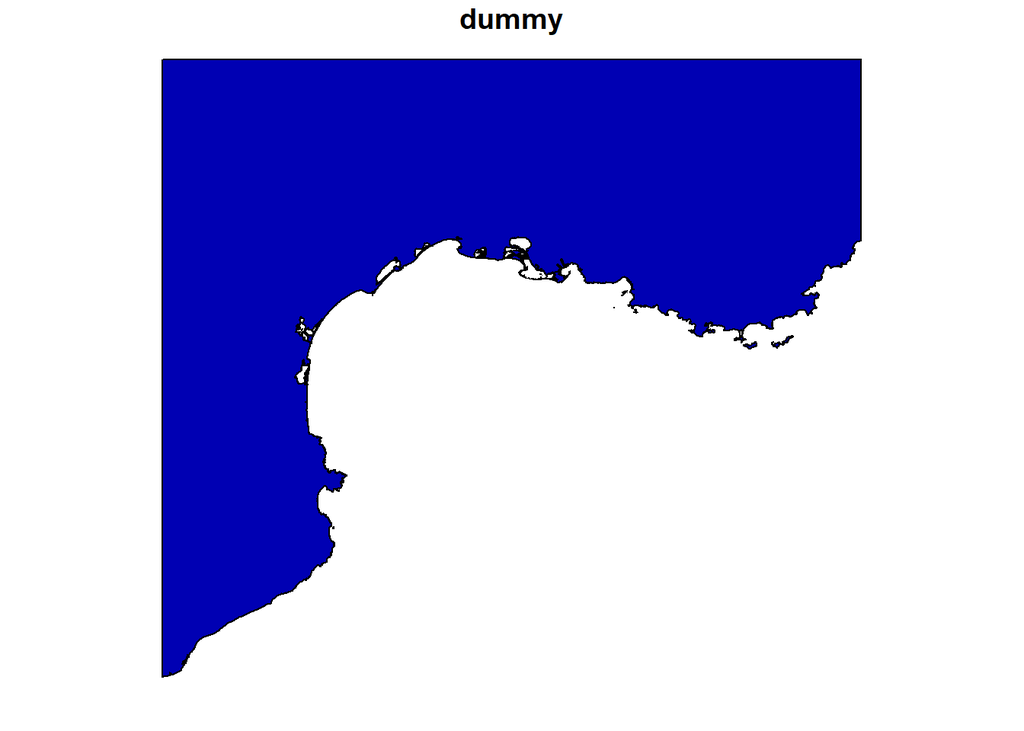

```r
shapes_subfolder <- "Data/Shape.files/"

GDL_extension <- "Extra/carto/shapefile/Europe_coastline_shapefile/"

GDL <- read_sf(paste(path, shapes_subfolder, GDL_extension, "GDL.shp", sep = ""))
plot(GDL)
```

```r
# NOTE: Grid extent should be 3, 6, 42.00, 43.55
GDL_crop <- st_crop(GDL, xmin=2.95, xmax=6.05, ymin=41.95, ymax=43.6)
```

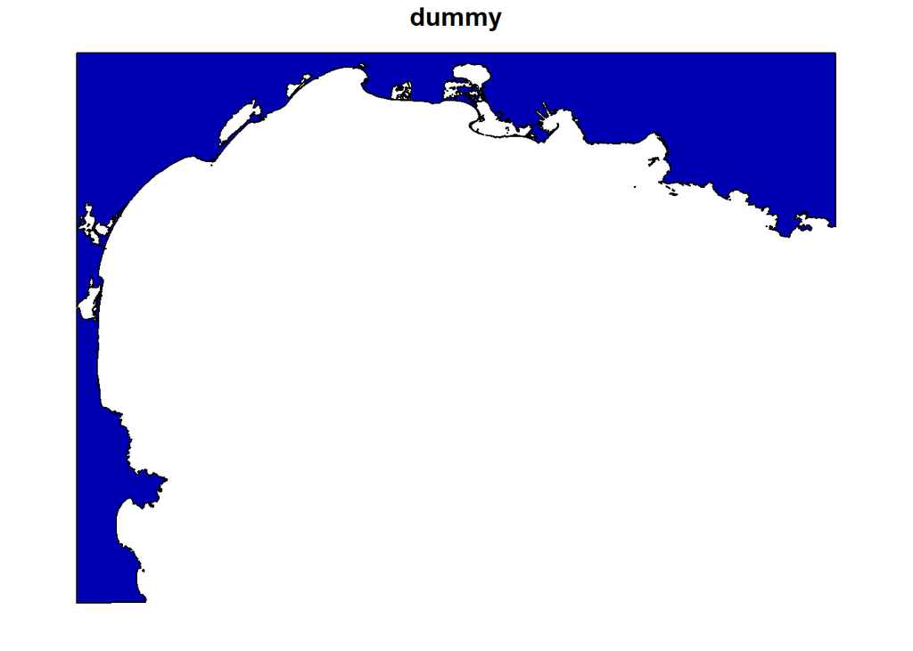

```r
plot(GDL_crop)
```

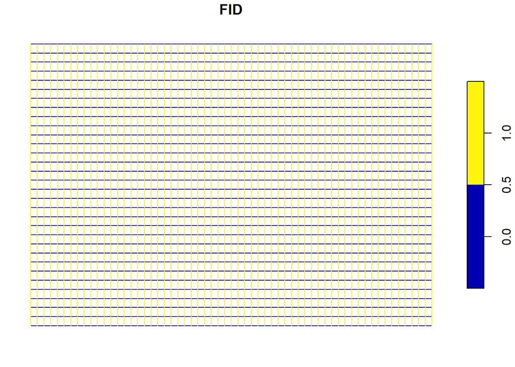

```r
grid <- read_sf(paste(path, shapes_subfolder, "Grid/grid.shp", sep = ""))
plot(grid)
```

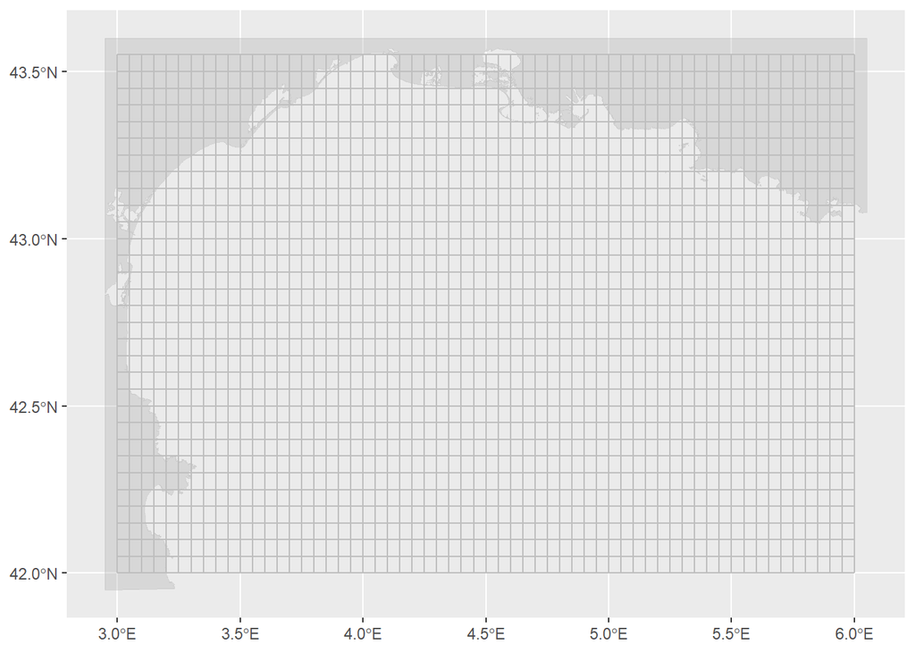

```r
p <- ggplot() +
  geom_sf(data=GDL_crop, color = alpha("grey", 1/2), size = 0.7, fill = 'darkgrey', alpha = .3) +
  geom_sf(data = grid, color = "grey")

p
```

```r
rm(GDL)
```

# Load Spatial Closures

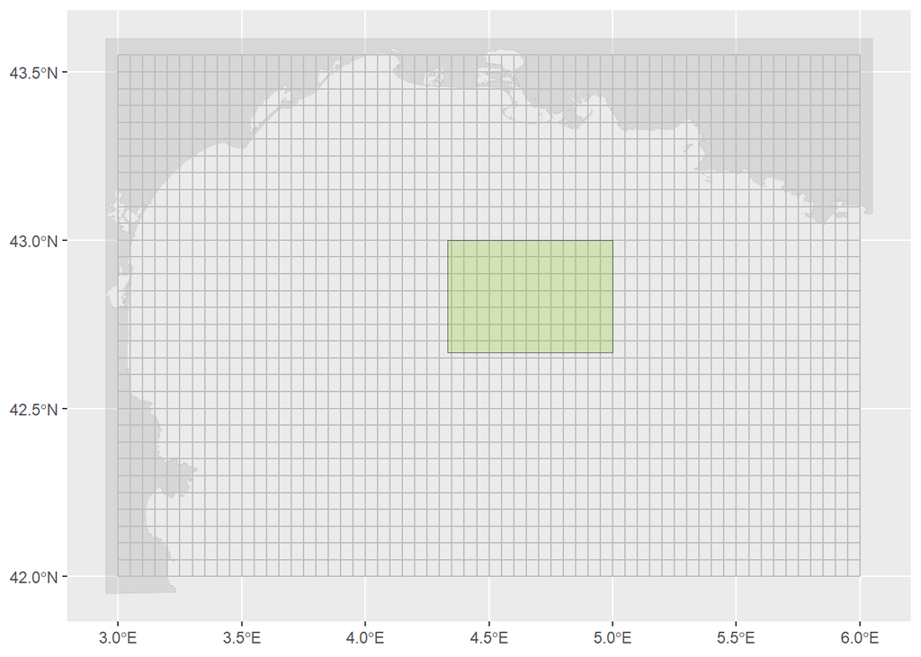

```r
FRA <- read_sf(paste(path, shapes_subfolder, "FRA/FRAs_WGS84.shp", sep = ""))
FRA <- FRA[1,]

p + geom_sf(data = FRA, fill = 'yellowgreen', alpha = 0.3)
```

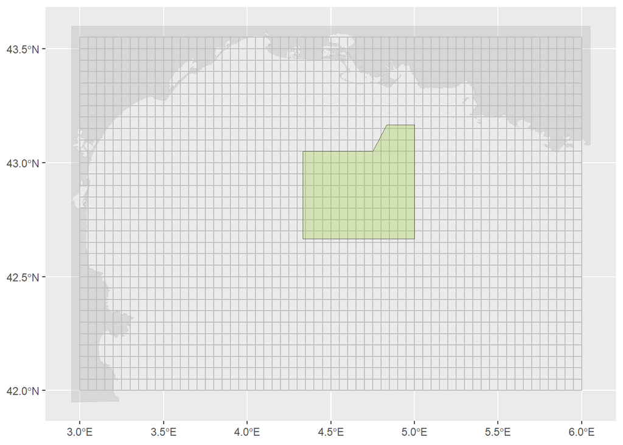

```r
#---------------------------------------------------------------------------

NewFRA_regulation <- read_sf(paste(path, shapes_subfolder, "NewFRA_regulation/boxPaca_polygon_4326.shp", sep = ""))

p + geom_sf(data = NewFRA_regulation, fill = 'yellowgreen', alpha = 0.3)
```

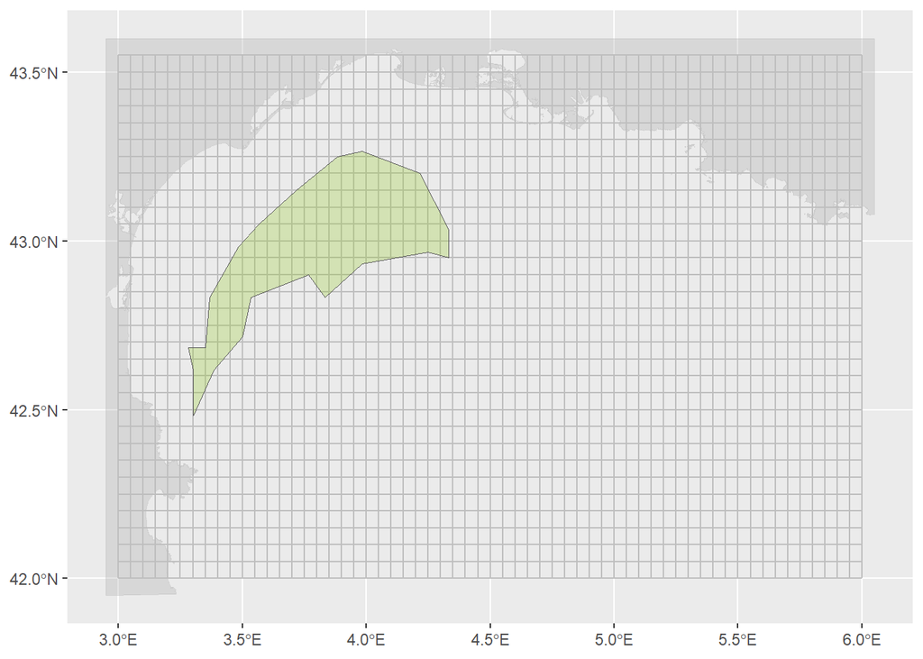

```r
#---------------------------------------------------------------------------

zone_90_100_simplified <- read_sf(paste(path, shapes_subfolder, "zone_90_100_simplified/zone_90_100_simplifiee_Visvalingram_0_05_deg_accroche_dm_polygon_4326.shp", sep = ""))

p + geom_sf(data = zone_90_100_simplified, fill = 'yellowgreen', alpha = 0.3)
```

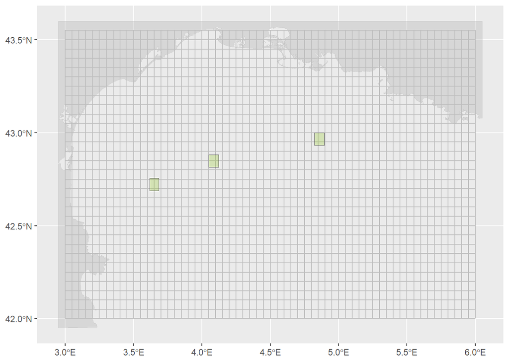

```r
#---------------------------------------------------------------------------

Offshore_closure_z1 <- read_sf(paste(path, shapes_subfolder, "Offshore_closures/zone1.shp", sep = ""))

Offshore_closure_z2 <- read_sf(paste(path, shapes_subfolder, "Offshore_closures/zone2.shp", sep = ""))

Offshore_closure_z3 <- read_sf(paste(path, shapes_subfolder, "Offshore_closures/zone3.shp", sep = ""))

# Group the Offshore_closures into one file
Offshore_permanent_spdf <- rbind(Offshore_closure_z1, Offshore_closure_z2, Offshore_closure_z3)

p + geom_sf(data = Offshore_permanent_spdf, fill = 'yellowgreen', alpha = 0.3)
```

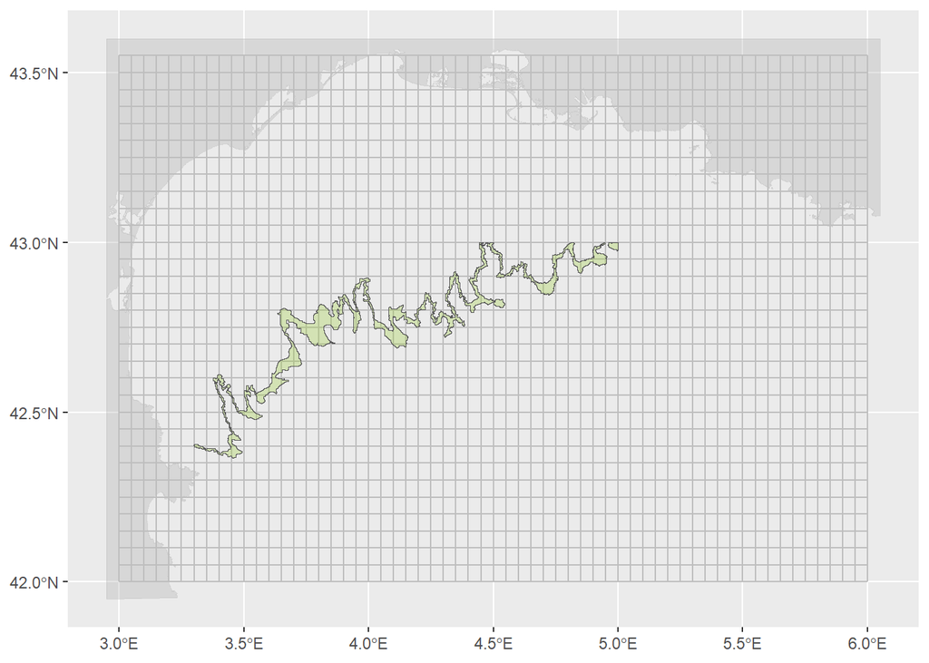

```r
#---------------------------------------------------------------------------

Offshore_closure_seasonal <- read_sf(paste(path, shapes_subfolder, "Offshore_closures/Offshore_closure_seasonal_final.shp", sep = ""))

p + geom_sf(data = Offshore_closure_seasonal, fill = 'yellowgreen', alpha = 0.3)
```

# Load Only Nominal Effort

```r
name_RData_6.4_effort <- 'EffNomtot_6.4_without-0s'
EffNomtot_6.4 <- fread(paste(path, "Data/", name_RData_6.4_effort,'.csv',sep = ''))

nameRDATA_clean <- 'EffNomtot_6.4_true_0s'
EffNomtot_6.4_matched <- fread(paste(path, "Data/", nameRDATA_clean, '.csv', sep = ''))

EffNomtot_6.4 <- rbind(EffNomtot_6.4, EffNomtot_6.4_matched)

rm(EffNomtot_6.4_matched)
```

# Join the simulation design table to the simulation output

Apply the names of the Scenarios in the column designating their numeric values and graft this to the Data.

```r
simuDesign <- '/MEDISIS/Part1.Reproducing.the.simulation.data/ISIS.Fish.Input.Tables/simulation_design_28'

simulationDesign <- fread(paste(dir, simuDesign,".csv", sep=""), sep=';', h=F)

colnames(simulationDesign) =  c('InitialAbundance','Recruitment','Connectivity','Scenarios')

simulationDesign$simu <- seq(0, 503, 1)

step <- unique(EffNomtot_6.4$step)
nbYear <- length(step)/12
YEAR <- sort(rep(seq(2015,2014+nbYear,1), 12))
MONTH <- rep(seq(1,12,1),nbYear)
tabStep <- data.frame(step, YEAR, MONTH)

EffNomtot_6.4 <- inner_join(EffNomtot_6.4, tabStep, by=c('step'))
EffNomtot_6.4 <- inner_join(EffNomtot_6.4, simulationDesign, by=c('simu'))

table_Sce_6.4 <- data.frame(Scenarios=as.character(c(0:27)),SceName=c("StatusQuo","Trawler_30_Red","Trawler_40_Red","Trawler_50_Red","Trawler_10_20_30","Trawler_10_17.5_25_32.5_40","Trawler_10_20_30_40_50","AllGears_30_Red","AllGears_40_Red","AllGears_50_Red","AllGears_10_20_30","AllGears_10_17.5_25_32.5_40","AllGears_10_20_30_40_50","Original_FRA_allYear","Northward_Expansion_of_FRA_Season","Northward_Expansion_of_FRA_allYear","90-100_Isobaths_Closure_Season","90-100_Isobaths_Closure_allYear","Offshore_Closures_Season","Offshore_Closures_allYear","Northward_Expansion_of_FRA_90-100m_Offshore_Closures_Combined","Northward_Expansion_of_FRA_90-100m_Offshore_allYear_Closures_Combined","Combined_Red_10_17.5-40_Northward_Expansion_of_FRA_90-100m_Offshore_Closures","Combined_Red_10_17.5-40_Northward_Expansion_of_FRA_90-100m_Offshore_Closures_allGears","Northward_Expansion_of_FRA_Offshore_Closures_Combined","Northward_Expansion_of_FRA_Offshore_allYear_Closures_Combined","Combined_Red_10_17.5-40_Northward_Expansion_of_FRA_Offshore_Closures","Combined_Red_10_17.5-40_Northward_Expansion_of_FRA_Offshore_Closures_allGears"))
```

# Filter data

Note that while we parameterise OTB_XST_18-24 and OTM_CMT_18-24 in ISIS-Fish, these are not active metier or they do not target hake.

```r
EffNomtot_6.4 <- subset(EffNomtot_6.4, !metier %in% c("OTB_XST_18-24","OTM_CMT_18-24"))

dim(EffNomtot_6.4)
# [1] 1935360  11
```

# Remove non-spatial scenarios except StatuQuo

We are only interested in where they fish and how they overlap. Value per unit effort (VPUE) will be the same for all other species.

```r
EffNomtot_6.4$Scenarios <- as.character(EffNomtot_6.4$Scenarios)

effort_6.4_metier_final <- inner_join(EffNomtot_6.4, table_Sce_6.4, by="Scenarios")

Drop1 <- c("Trawler_30_Red","Trawler_40_Red","Trawler_50_Red","Trawler_10_20_30","Trawler_10_17.5_25_32.5_40","Trawler_10_20_30_40_50","AllGears_30_Red","AllGears_40_Red","AllGears_50_Red","AllGears_10_20_30","AllGears_10_17.5_25_32.5_40","AllGears_10_20_30_40_50")

effort_6.4_metier_final <- subset(effort_6.4_metier_final, !SceName %in% Drop1)

# For Nominal Effort by métier:
effort_month_metier <- setNames(aggregate(value ~ metier + YEAR + MONTH + simu + InitialAbundance + Recruitment + Connectivity + Scenarios + SceName, data = effort_6.4_metier_final, sum), c("METIER", "YEAR", "MONTH", "simu","InitialAbundance", "Recruitment", "Connectivity", "Scenarios", "SceName", "Nominal_Effort"))

dim(effort_month_metier)
# [1] 794880  10

dim(unique(effort_month_metier))
# [1] 794880  10

rm(EffNomtot_6.4, effort_6.4_metier_final)
```

# For spatial zone defs, merge required simulation outputs

Here we need the “ZonesDefinition.csv” and “MailleDefinition.csv” files. These can be found in the “isis-fish-4/isis-database/simulations/” subfolder. We also want to merge the nominal effort outputs with the ZoneCellsDefs file we are creating.

Since we are only interested in the zone cell definitions so you can just use the first simulation output folder. All zones and cell definitions are constant throughout the model.

```r
cellDefs <- fread(paste(simFolder, StatusQuo.scen,
                        "resultExports/MailleDefinition.csv", sep=""),
                  header = T, sep = ";")

zoneDefs <- fread(paste(simFolder, StatusQuo.scen,
                        "resultExports/ZonesDefinition.csv", sep=""),
                  header = T, sep = ";")

ZoneCellDefs <- inner_join(cellDefs, zoneDefs, by = 'cell')

Drop2 <- c("200m","90m_100m")

ZoneCellDefs_mod <- subset(ZoneCellDefs, !zone %in% Drop2)

# Having more to join on takes last memory
ZoneCellDefs_mod <- inner_join(ZoneCellDefs_mod, tabStep, by = c('step'))

ZoneCellDefs_mod <- subset(ZoneCellDefs_mod)

dim(ZoneCellDefs_mod)
# [1] 740280  7

unique(dim(ZoneCellDefs_mod))

unique(ZoneCellDefs_mod$zone)
```

# Restructure the ZoneCellDefs data.frame to match

Because metier zones are structured differently than the effort metier, we must manipulate the character strings a bit.

1. Group the métiers.

```r
Gillnetters <- c("FrenchGillnetters1")

LLS_ESP <- "SpanishLongliners"

OTB_ESP <- "SpanishOTB"

All_others <- c("24-40_GPV_OTB", "24-40_GPV_OTT", "24-40_GPV_OTM",
                "18-24_GPV_OTT", "18-24_GPV_OTB", "24-40_XST_OTB",
                "24-40_XST_OTT", "24-40_CST_OTT", "24-40_XST_OTM",
                "24-40_CST_OTB", "24-40_CST_OTM", "18-24_CST_OTB",
                "24-40_CMT_OTM", "24-40_CMT_OTB", "24-40_GST_OTB",
                "18-24_XST_OTT", "18-24_CMT_OTB", "18-24_GST_OTB",
                "18-24_XMA_OTB", "18-24_XMA_OTM", "18-24_GST_OTM")

metier_special <- c(Gillnetters, LLS_ESP, OTB_ESP)
```

2. Substitute métiers in metier_special.

```r
MetierZones_special <- ZoneCellDefs_mod %>%
  filter(zone %in% metier_special)

dim(MetierZones_special)
# [1] 115320   8

MetierZones_special$metier <- MetierZones_special$zone

MetierZones_special$metier <-gsub("SpanishOTB", "OTB_ESP", MetierZones_special$metier)

MetierZones_special$zone <-gsub("SpanishOTB", "OTB_ESP", MetierZones_special$zone)

MetierZones_special$metier <-gsub("SpanishLongliners", "LLS_ESP", MetierZones_special$metier)

MetierZones_special$zone <-gsub("SpanishLongliners", "LLS_ESP", MetierZones_special$zone)

MetierZones_special$metier <-gsub("FrenchGillnetters1", "GNS_FRA", MetierZones_special$metier)

MetierZones_special$zone <-gsub("FrenchGillnetters1", "GNS_FRA", MetierZones_special$zone)

unique(MetierZones_special$metier)

# Retain only the distinct values.
MetierZones_special2 <- distinct(MetierZones_special)

dim(MetierZones_special2)
# [1] 115320   8
```

3. Substitute métiers in All_others.

```r
Rest_MetierZones <- ZoneCellDefs_mod %>%
  filter(zone %in% All_others)

dim(Rest_MetierZones)
# [1] 461160  7

Rest_MetierZones$VesselSize <- substr(Rest_MetierZones$zone, 1, 5)

Rest_MetierZones$Port <- substr(Rest_MetierZones$zone, 7, 9)

Rest_MetierZones$Gear <- substr(Rest_MetierZones$zone, 11, 13)

Rest_MetierZones$metier <- paste0(Rest_MetierZones$Gear, "_", Rest_MetierZones$Port, "_", Rest_MetierZones$VesselSize, sep = '')

unique(Rest_MetierZones$metier)

Rest_MetierZones <- Rest_MetierZones[,-c(8:10)]

# Check output
Rest_MetierZones2 <- distinct(Rest_MetierZones)

dim(Rest_MetierZones2)
# [1] 461160  8
```

4. Merge everything together.

```r
MetierZones <- rbind(Rest_MetierZones2, MetierZones_special2)

dim(MetierZones)
# [1] 576480  8

names(MetierZones)[8] <- "METIER"

unique(MetierZones$zone)

MetierZones$zone <- MetierZones$METIER

# Check output
MetierZones2 <- distinct(MetierZones)

dim(MetierZones2)
# [1] 576480  8
```

# Extract the spatial closures and population zones

Merge the remaining zones and create a unique id for sources of uncertainty by scenario.

```r
EffortMetierZones.unique <- inner_join(MetierZones2, effort_month_metier,
                                       by = c("YEAR", "MONTH", "METIER"))
unique(EffortMetierZones.unique$zone)

dim(EffortMetierZones.unique)
# [1]

rm(cellDefs, MetierZones, effort_month_metier, ZoneCellDefs, Rest_MetierZones, MetierZones_special, zoneDefs)

Spatial_def_names <- c("ContinentalShelf", "ContinentalSlope", "Offshore_seasonal_expansion", "90_100m_isobath_closure", "Original_FRA", "Northward_Expansion_of_FRA", "Offshore_fixed")

Spatial_defs <- subset(ZoneCellDefs_mod, zone %in% Spatial_def_names)
```

# Merge the spatial closure cells table with the effort table

Remember that there will be metier zone cells that do not match with spatial closures, these should be conserved. However, after further investigation, there are 76 cells that occur in the metier zone definition files which are no defined in the population zone files. The effort for these metier zones should be unaffected because of the calibration steps, but any findings where spatial closures are applied will be effected, especially with the gillnetters. Unfortunately this is not something that can be corrected for in the model because no data otherwise exists to define these cells.

Therefore, while they are included in the zone definition maps, when calculating effort with a closure, these 76 cells should also be removed. An outline of their definition is provided, however for when more information becomes available so that they can be updated.

```r
EffortMetierZones.unique_ref <- EffortMetierZones.unique[(EffortMetierZones.unique$InitialAbundance == "0" & EffortMetierZones.unique$Recruitment == "0" & EffortMetierZones.unique$Connectivity == "0"), ]

# Create a zone vector with the same values as METIER
EffortMetierZones.unique_ref$zone <- EffortMetierZones.unique_ref$METIER

# Find and incomplete values
EffortMetierZones.unique_check <- EffortMetierZones.unique_ref[!complete.cases(EffortMetierZones.unique_ref),]

EffortMetierZones.unique_check

# Important, use left_join to conserve all effort values (some cells have no corresponding zone)
ZonesPLUS.unique.testleft <- left_join(EffortMetierZones.unique_ref, Spatial_defs, by = c("cell", "longitude", "latitude", "YEAR", "step", "MONTH"))
dim(ZonesPLUS.unique.testleft)
# [1] 12933120  16

# Check if there are non-unique values or duplicates
ZonesPLUS.unique.testleft.distinct <- distinct(ZonesPLUS.unique.testleft)
```

## Re-arrange data frame for easier zone definition plotting

NA values were discovered and explored in a later code chunk.

```r
# Create a new vector for fish population zones
Pop_Region <- c("ContinentalShelf", "ContinentalSlope")

# Rearrange the like data so that rows bound by cell... this will be used for the zone definition plots only
ZonesPLUS2.melt <- reshape2::melt(ZonesPLUS.unique.testleft.distinct[, c("cell", "longitude", "latitude","step", "zone.x", "YEAR","MONTH","METIER","simu", "InitialAbundance", "Recruitment", "Connectivity", "Scenarios", "SceName", "Nominal_Effort", "zone.y")], id = c("cell", "longitude", "latitude", "YEAR", "MONTH", "METIER", "simu", "InitialAbundance", "Recruitment", "Connectivity", "Scenarios", "SceName", "Nominal_Effort", "step"))

# check for NA values
unique(is.na(ZonesPLUS2.melt))

# If Na's are present, check which rows
ZonesPLUS2.melt1 <- ZonesPLUS2.melt[is.na(ZonesPLUS2.melt$value),]

unique(ZonesPLUS2.melt1)

unique(ZonesPLUS2.melt1$cell)

# Remove all NA values from the data set
ZonesPLUS2.melt1.1 <- ZonesPLUS2.melt[!is.na(ZonesPLUS2.melt$value),]

dim(ZonesPLUS2.melt1.1)
# [1] 25729920   16

head(ZonesPLUS2.melt1.1)

# Rename columns (This will be used for Zone Definitions)
ZonesPLUS2.melt2 <- ZonesPLUS2.melt1.1[,-15]

names(ZonesPLUS2.melt2)[15] <- "zone"

# Isolate all melted cells that correspond to the actual closure zones
ZonesPLUS.unique.testleft.distinct2 <- subset(ZonesPLUS2.melt2, !zone %in% Pop_Region)

dim(ZonesPLUS.unique.testleft.distinct2)
# [1] 16694400   15

# Remove redundant values
ZonesPLUS.unique.testleft.distinct2 <- distinct(ZonesPLUS.unique.testleft.distinct2)

dim(distinct(ZonesPLUS.unique.testleft.distinct2))
# [1] 12933120  15
```

# Restructure closures and métier zones to join on

```r
# Create a list of the closure scenarios
Closurezones <- c("90_100m_isobath_closure", "Original_FRA", "Northward_Expansion_of_FRA", "Offshore_seasonal_expansion", "Offshore_fixed")

# These are the closure scenarios that we will later merge into the same table with metier zones
ZonesPLUS.unique.testleft.distinct2.splt.cl <- subset(ZonesPLUS.unique.testleft.distinct2, zone %in% Closurezones)

dim(ZonesPLUS.unique.testleft.distinct2.splt.cl)
# [1] 3761280  15

# These are you metier zones and that we will later merge into a table with closure scenarios
ZonesPLUS.unique.testleft.distinct2.nonsplt.cl <- subset(ZonesPLUS.unique.testleft.distinct2, !zone %in% Closurezones)

dim(ZonesPLUS.unique.testleft.distinct2.nonsplt.cl)
# [1] 9171840  15

dim(distinct(ZonesPLUS.unique.testleft.distinct2.nonsplt.cl))
# [1] 9171840  15

# Our final table now has two zones per each cell that we can apply condition to
combined_fishing_effort_closure <- left_join(ZonesPLUS.unique.testleft.distinct2.nonsplt.cl, ZonesPLUS.unique.testleft.distinct2.splt.cl, by = c("cell", "longitude", "latitude", "YEAR","MONTH","METIER","simu", "InitialAbundance", "Recruitment", "Connectivity", "Scenarios", "SceName"))

head(combined_fishing_effort_closure)

dim(combined_fishing_effort_closure)
# [1] 9667200  18

# Note that you will have NA values in "zone.y"
unique(combined_fishing_effort_closure$zone.y)
# [1] NA                            "90_100m_isobath_closure"
# [3] "Offshore_seasonal_expansion" "Offshore_fixed"
# [5] "Original_FRA"                "Northward_Expansion_of_FRA"

# Replace these NA values with their corresponding MetierZone
fill_w_MetierZone <- combined_fishing_effort_closure[is.na(combined_fishing_effort_closure$zone.y), ]

fill_w_MetierZone$zone.y <- fill_w_MetierZone$zone.x

combined_fishing_effort_w_closure <- subset(combined_fishing_effort_closure, !is.na(zone.y))

combined_fishing_effort_closure.final <- rbind(fill_w_MetierZone, combined_fishing_effort_w_closure)

summary(combined_fishing_effort_closure.final)

# Remove Nominal_Effort.y and step.y
combined_fishing_effort_closure.final <- combined_fishing_effort_closure.final[,-c(16,17)]

names(combined_fishing_effort_closure.final)[16] <- "Zone"

names(combined_fishing_effort_closure.final)[15] <- "MetierZone"

names(combined_fishing_effort_closure.final)[14] <- "step"

names(combined_fishing_effort_closure.final)[13] <- "Nominal_Effort"

colnames(combined_fishing_effort_closure.final)

fwrite(combined_fishing_effort_closure.final, file = paste(path, "Data/", "combined_fishing_effort_closure.final.csv", sep = ""))
```